# Win Probability Assignment

Clayton Jones

2025-07-20

## 1. Model Development

For this assignment, I developed a logistic regression model that calculates the win probability for the home team in an NFL game on a play-by-play basis. The model was trained using data from the 2022-2024 NFL seasons. All data was imported using the nflreadR package in R created by Ho and Carl (2025), which pulls data from the nflfastR package created by Carl and Baldwin (2025). All analysis was done in R.

After importing the data using the load_pbp() function, the data needed to be cleaned and prepped for the purposes of creating the model. First, rows where the “play_type” value is “no_play” or null were removed, as well as all overtime plays. “no_play” or null values indicated the start of a game, start of a quarter, timeout, penalty, etc. Next, I appended the dataframe with several different values: “winning_team” which identified who won the game, “team_with_ball_win” which identified if the team who possessed the ball went on to win, “home_team_has_ball” which identified if the home team possessed the ball, and “team_with_ball_received” which identified whether the team in possession of the ball received the opening kickoff.

The next step was to identify the variables that would be used to create the model. There were actually two models created: a simpler model with only a few input variables, and a larger model that included those same input variables plus a few more. For both variables, the target variable was the binary variable that identified whether the team who possessed the ball went on to win the game, “team_with_ball_win.” The input variables for the first model were: “score_differential” which identified score differential for the team with the ball (i.e. if the team with the ball was losing by 7, the value would be -7), “yardline_100” which identified how far away from the opposing goal line at the start of the play, “game_seconds_remaining” which identified how much time remained in the game at the start of the play, “down” which identified which down it was, and “distance” which identified distance to the chains. The second model included these input variables plus the following: “team_with_ball_received” as described above, as well as “posteam_timeouts_remaining” and “defteam_timeouts_remaining” which identified how many timeouts the team with possession of the ball and the defending team had, respectively.

The data was split into training and testing data with an 80/20 split. Then, the models were created using the glm() function, including the “family = binomial” declaration because these were to be logistic regression models with a binary target variable. The summary output for the first model built on the training set can be seen below, and the output for the second model can be seen in Appendix A.

```
##
## Call:
## glm(formula = team_with_ball_win ~ score_differential + yardline_100 +
##     game_seconds_remaining + down + ydstogo, family = binomial,
##     data = train)
##
## Coefficients:
##                          Estimate Std. Error z value Pr(>|z|)
## (Intercept)             1.088e+00  3.390e-02  32.086  < 2e-16 ***
## score_differential      1.735e-01  1.297e-03 133.747  < 2e-16 ***
## yardline_100           -8.547e-03  3.378e-04 -25.303  < 2e-16 ***
## game_seconds_remaining -6.636e-06  7.411e-06  -0.895    0.371
## down                   -1.241e-01  8.135e-03 -15.257  < 2e-16 ***
## ydstogo                -1.500e-02  2.034e-03  -7.373 1.67e-13 ***
## ---
## Signif. codes:  0 '***' 0.001 '**' 0.01 '*' 0.05 '.' 0.1 ' ' 1
##
## (Dispersion parameter for binomial family taken to be 1)
##
##     Null deviance: 129309  on 93291  degrees of freedom
## Residual deviance:  95610  on 93286  degrees of freedom
##   (10213 observations deleted due to missingness)
## AIC: 95622
##
## Number of Fisher Scoring iterations: 5
```

Looking at the table, it can be observed that all input variables except time remaining in the game have a statistically significant relationship with winning. The same can be said for the bigger model. When comparing the models, the larger model has an Akaike Information Criterion (AIC) of 95133 versus an AIC of 95622 for the simple model. This indicates that the model with the added input variables better fits the data and is a better-quality model.

The next step was to calculate the win probability for each play for both models. This was done by using the predict() function, adding a column to the test dataframe with the predicted win probability for the team with possession of the ball based on the input variables and the coefficients from the model. Using logic, another column was created that contained win probability for the home team to more easily be able to of create win probability charts. Some manual imputation had to be made for kickoffs, extra points, and two-point conversions because they lacked down and distance and therefore were not able to have predicted values. To account for this, opening kickoffs were given the value of 0.5, and extra points and two-point conversions just took the value of the first play after.

In order to better quantify the difference in performance between the two models, I created a binary column in the test dataframe that identified whether the home team won the game and created two other columns by converting the win probabilities from both models into binary predictions for whether the home team would win. I used 0.5 as the threshold, so a win probability of 0.5 or above would result in a prediction of the home team winning the game. From these columns, confusion matrices were made, and the model accuracy was calculated by dividing the number of correct predictions by the number of total predictions made. For example, an accuracy score of 80% would mean that for a given play, the win probability would correctly predict the winner of a game 80% of the time. The simple model had an accuracy score of 0.730, and the bigger model had an accuracy of 0.731, meaning that the models performed roughly the same. However, given that it had slightly higher accuracy and a lower AIC, the bigger model is the model that is used for the rest of the analysis.

## 2. 2024 Cincinnati Bengals @ Baltimore Ravens

In order to examine the accuracy of the model, a game from the 2024 season was selected. The Cincinnati Bengals @ Baltimore Ravens game on 11/7/24 was a high scoring game with lots of back-and-forth scoring, and therefore seemed like a good game to select. There were lots of different plays with high shifts in win probability. To examine the plays with largest shifts in win probability, a column “win_prob_added” needed to be created that calculated the difference in win probability from one play to another. For each play, this was done by taking the difference between win probability at the start of the play after and win probability at the start of the play. This can be defined as win probability added because it shows how much win probability changed based on the result of the specific play. The five plays with the highest shifts in win probability, or “win_prob_added”, can be seen below in Table 1.

Table 1: Top 5 Plays in Win Probability Added for Bengals @ Ravens in 2024

| Description | Score Differential | Down | Yds to Go | Yardline (100) | Time Remaining (seconds) | Win Probability Added |
| --- | --- | --- | --- | --- | --- | --- |
| (13:44) (No Huddle, Shotgun) 8-L.Jackson pass short left to 16-T.Wallace for 84 yards, TOUCHDOWN. | -7 | 3 | 2 | 84 | 824 | 0.1949850 |
| (5:50) (Shotgun) 9-J.Burrow pass deep middle to 1-J.Chase for 70 yards, TOUCHDOWN. | -7 | 1 | 10 | 70 | 350 | 0.1726765 |
| (5:56) (Shotgun) 8-L.Jackson pass short left to 89-M.Andrews for 18 yards, TOUCHDOWN. | -1 | 3 | 9 | 18 | 356 | 0.1641343 |
| (9:29) (Shotgun) 9-J.Burrow pass incomplete deep left to 81-J.Burton. | 1 | 4 | 2 | 34 | 569 | 0.1295547 |
| (11:02) (No Huddle, Shotgun) 9-J.Burrow pass short left to 80-A.Iosivas to BAL 5 for 19 yards (32-M.Williams). | 0 | 3 | 4 | 24 | 3362 | 0.1173663 |

By no surprise, the top three plays were all touchdowns, with the first two being long touchdowns of 84 yards and 70 yards respectively. All three of these scores also came late in the game. Both touchdowns also took their teams from down 7 points to down 1 and the game could be tied with the extra point. The third touchdown took the Ravens from down 1 to up 5 with less than 6 minutes left in the game. Logically, these plays make sense as to why they would have large swings in win probability. The fourth play is a failed fourth down in opponent territory in the fourth quarter while leading, which logically would also make sense. A conversion would have added win probability for the Bengals, but failing and giving the ball back to the Ravens decreased the Bengals’ win probability. The fifth play, a first down on the first drive of the game sticks out a little bit in comparison to the rest. It was a third down play, in Baltimore territory, in the first quarter, that resulted in a first down. I would not think that this would be a top five play in terms of shifting win probability, but I would imagine it is because there is a big difference in scoring a touchdown and kicking a field goal on the opening drive. If the model were refined a little bit more, I would imagine that this play would not be in the top five.

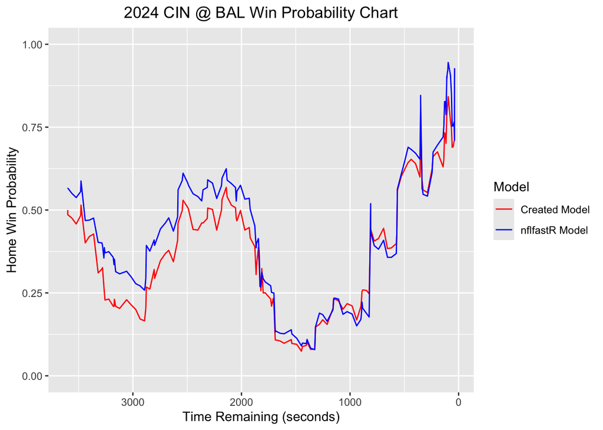

Looking at the graph, it can be seen that the models are fairly similar. When there are large swings in win probability for one model, there are large swings in win probability for the other. However, there are a few key differences. One key difference is that included model does not start at a home win probability of 0.500. I would assume that there are factors for home field, but also team strength. These are factors that could be included with further refinement of the model I created. Towards the end of the game, the included model also trends closer to a state of 1, and I would imagine that in the case of the visiting team winning it would trend closer to 0. The included model is more complex and probably has much more data to build off. Using the same accuracy measure as described before, the include included model had an accuracy score of 0.735 on the test set. As previously mentioned, the model I created had an accuracy score of 0.731 on the test set. So, the included model was slightly more accurate than the model I created. I would think that the more input variables I used and more seasons of data I built the model off, the more like the included model it would become, and the better it would perform.

## 3. Limitations and Future Directions

There are a number of ways that the model is limited and could be improved in the future. First, the model does not incorporate team strength. In the model already included in the data, past performance data, team strength, and situational factors are considered when calculating the win probabilities (Elmore and Urbaczewski 2024). I don’t know what exact measure or measures would be used for team strength, but more research could be done on to determine the best way to accurately include team strength. The model also does not know how to create predictions for kickoffs, extra points, and two-point conversions. These plays can have an impact on win probability, so determining how to create predictions for them would help the model improve. There are other ways that the specific win probability model could be improved, but these two appear to be the biggest.

Upon further refinement of the model, it could be used to help teams or coaches make in game decisions. In particular, the model could help with fourth down decisions, when deciding whether to punt or go for it, or to kick a field goal or go for it. The model could take the potential outcomes of both decisions and examine how win probability is affected based on them, therefore determining the expected win probability added for either decision. The coach could then aim to make the decision of optimizing win probability, deciding to go with whichever decision has the highest expected win probability added. Eric Eager (2023) did a study quantifying decisions made by coaches from 2014-2022, examining how well head coaches were making decisions of going for it or kicking in relation to other coaches. The analysis done by Eager (2023) showed that making the “right” decisions (i.e. going for it when the expected win probability of going for it is higher and vice versa) and actual win probability gained from these decisions were similarly correlated in consecutive years. The same could be done for several different in-game decisions, such as the decision to kick the extra point or attempt a two-point conversion. Using a win probability model to help with in-game decision making could allow the team to make smarter decisions that realistically impact the probability of winning the game.

## 4. Fourth Down Decision-Making Analysis

Like Eager’s analysis, I wanted to show how expected points added and win probability could be used together to make in game decisions to go for it or kick a field goal on certain fourth downs. fourth down decisions can be crucial at all times of the game, but I wanted to focus on fourth downs that could be the most crucial, considering field position, time of game, and score differential. The same data from 2022-2024 was used from before, but if was filtered to fourth downs that occurred in the second half of games, with a score differential of 14 or less, and on the opponent’s 35-yard line or closer to the end zone.

Having already calculated the win probability added for every play earlier, now I needed to find the average expected points added for either kicking the field goal or going for it. nflsimulatoR is an R package created by Elmore, Williams, and Palmquist (2022) for simulating NFL plays and drives, and has a function expected_pts_fourth() that can calculate the expected points added for a fourth down play for a specified distance and field position, based on NFL play-by-play data. Thus, using the 2022-2024 data I used before, I used the function to calculate the expected points for both added for both kicking and going for it for each fourth down play described above.

Next, I categorized each play based on the expected points added. If kicking had a higher expected points added, then I put the play in the “should have kicked” category. If going for it had a higher expected points added, I put it in the “should have gone for it” category. Now, the “should have” decisions could be compared to the real decisions, in order to see how these decisions affected win probability. Table 2 below shows each event, the average hypothetical win probability added from each event, and the frequency.

Table 2: Fourth Down Decisions 2022-2024

| Event | Average Win Probability Added | Frequency |
| --- | --- | --- |
| Should have gone for it, kicked | -0.0157520 | 450 |
| Should have gone for it, went for it | 0.0033709 | 292 |
| Should have kicked, kicked | 0.0035345 | 469 |
| Should have kicked, went for it | -0.0092515 | 48 |

### References

Carl, Sebastian, and Ben Baldwin. 2025. nflfastR: Functions to Efficiently Access NFL Play by Play Data. R package version 5.1.0.9000,  
https://www.nflfastr.com/.  
Eager, Eric. 2023. “SumerSports In-Game Coaching Model: An Introduction.” SumerSports. February 28, 2023.  
https://sumersports.com/the-zone/sumersports-in-game-coaching-model-an-introduction/.  
Elmore, Ryan, and Andrew Urbaczewski. 2024. Introduction to Sports Analytics Using R. Prospect Press.  
Elmore, Ryan, Ben Williams and Will Palmquist. 2022. NFLSimulatoR: Simulating Plays and Drives in the NFL. R package version 0.4.0,  
https://github.com/rtelmore/NFLSimulatoR/.  
Ho, Tan, and Sebastian Carl. 2025. nflreadr: Download ‘nflverse’ Data. R package version 1.4.1.07,  
https://nflreadr.nflverse.com.

### Appendix A

```
##
## Call:
## glm(formula = team_with_ball_win ~ score_differential + yardline_100 +
##     game_seconds_remaining + down + ydstogo + posteam_timeouts_remaining +
##     defteam_timeouts_remaining + team_with_ball_received, family = binomial,
##     data = train)
##
## Coefficients:
##                              Estimate Std. Error z value Pr(>|z|)
## (Intercept)                 1.226e+00  4.895e-02  25.040  < 2e-16 ***
## score_differential          1.758e-01  1.315e-03 133.714  < 2e-16 ***
## yardline_100               -8.609e-03  3.392e-04 -25.379  < 2e-16 ***
## game_seconds_remaining     -1.070e-08  7.995e-06  -0.001    0.999
## down                       -1.257e-01  8.164e-03 -15.397  < 2e-16 ***
## ydstogo                    -1.499e-02  2.041e-03  -7.344 2.07e-13 ***
## posteam_timeouts_remaining  1.144e-01  1.246e-02   9.183  < 2e-16 ***
## defteam_timeouts_remaining -1.073e-01  1.320e-02  -8.131 4.26e-16 ***
## team_with_ball_received    -3.123e-01  1.599e-02 -19.532  < 2e-16 ***
## ---
## Signif. codes:  0 '***' 0.001 '**' 0.01 '*' 0.05 '.' 0.1 ' ' 1
##
## (Dispersion parameter for binomial family taken to be 1)
##
##     Null deviance: 129309  on 93291  degrees of freedom
## Residual deviance:  95115  on 93283  degrees of freedom
##   (10213 observations deleted due to missingness)
## AIC: 95133
##
## Number of Fisher Scoring iterations: 5
```